# evolution of parasite countermeasures

5 November 2025

# General principles

- two stages of evolution: *de novo* mutation and selection
- limiting factors in *de novo* mutation
  - mutation rate (per locus/per genome)
  - population size
  - generation time
  - rate appearance of new mutations = (mutation rate × pop size)/(generation time)
  - mutational **spectrum**: what can mutations achieve?
- limiting factors in selection:
  - selection differential
    - benefits (= prob of encountering antibiotic × benefit of resistance)
    - costs [metabolic/energetic; reduced efficiency]
      - **compensatory** mutations (reduce cost)
  - pop size (drift vs selection; bottlenecks in between-host transmission)
  - variation in selection (within- vs between-host)
  - recombination and/or horizontal transmission via mobile elements (plasmids etc.)
- competition between susceptible and resistant strains (Lipsitch & Samore, 2002)

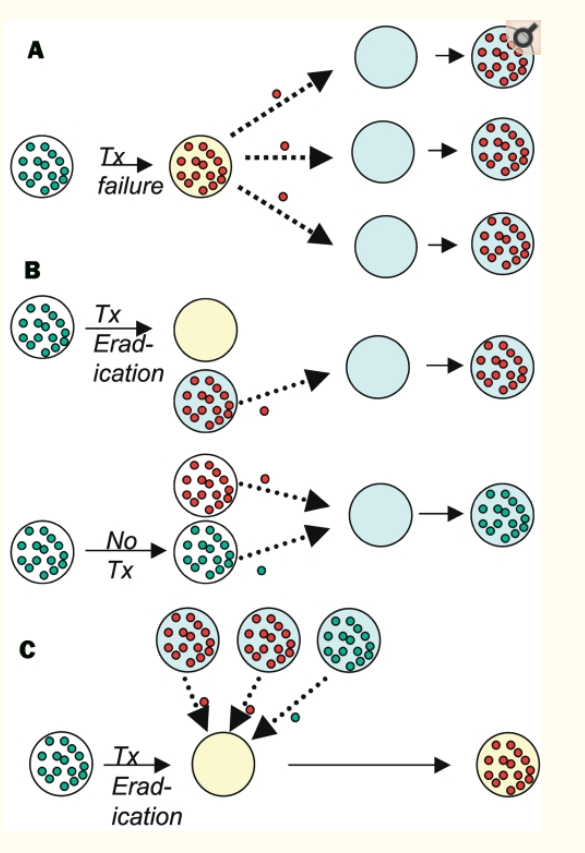

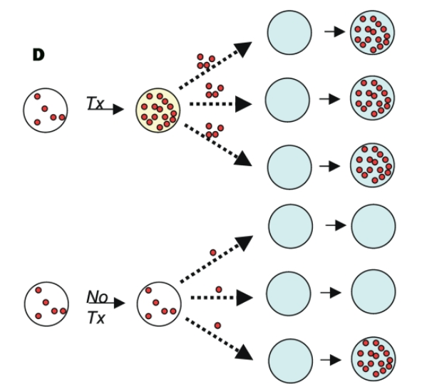

1. resistant bacteria take over during treatment failure (within-host competition)
2. resistant bacteria take advantage of reduced transmission by treated hosts (between-host)
3. resistant bacteria colonize a treated host (empty patch)
4. resistant bacteria take advantage of side effects (bystander effects)

# Bacteria

## Mechanisms

- because bacteria and animals are biochemically different, can use substances that disrupt bacterial but not animal metabolic processes
- many biologically derived
  - fungi (penicillin!) (Karwehl & Stadler, 2016)
  - soil bacteria (esp *Streptomyces*; streptomycin, tetracycline)
  - (also chemical/synthetic, e.g. derived from dyes - *sulfa drugs*)
- because antibiotics have been around “forever”, so has antibiotic resistance (D’Costa et al., 2011)
  - but presence **as mobile elements** may be recent, human/animal derived (Ebmeyer et al., 2021)
  - often present in antibiotic *producers* (Benveniste & Davies, 1973)
- huge problem, e.g. mdrMRSA ([multi-drug resistant], methicillin-resistant *Staphylococcus aureus*), extensively drug-resistant (XDR) tuberculosis (Centers for Disease Control, 2020)
  - threatens to wipe out disease cures …
- horizontal transfer is rampant
  - resistance gene can be anywhere in the microbiome …
  - **collateral** or **non-target selection** (Llewelyn et al., 2017)
  - also makes it easier to lose resistance when no longer required
  - thus resistance is usually/often pre-existing
- mechanisms of action:
  - pumps (“efflux system”: remove toxic substances from the cell)
  - inactivation or degradation/detoxification
  - altered molecular conformulation (Finken et al. (1993): “… resistance against multiple unrelated drugs in *M. tuberculosis* is not caused by a single event involving resistance to a panel of antibiotics, e.g. an altered permeability barrier, but rather conferred by an accumulation of multiple mutational events specific for each drug’s target respectively as demonstrated for streptomycin”)
- antibiotics are *effectors* (not recognizers)
- cost of resistance; are resistance alleles lost or compensated in the absence of antibiotics? (Bjorkholm et al., 2001; Levin et al., 2000)

## Implications for antibiotic use

- avoid overuse! “antibiotic conservation”
- regulate agricultural use
  - for human-to-human transmission, regulating agriculture may be too late once resistance is already established in humans (Smith et al., 2002)

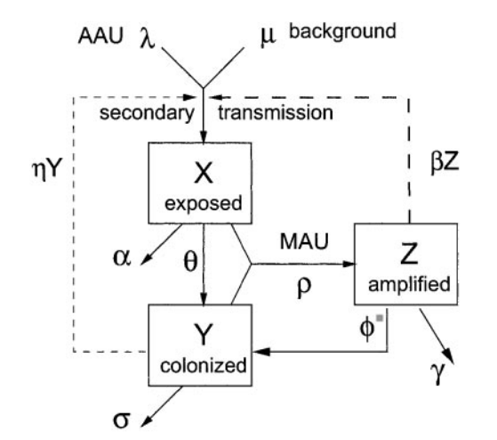

  - but regulation still helps with spillover infections (Lipsitch et al., 2002)
- “the long-term benefit of single drug treatment from introduction of the antibiotic until a high frequency of resistance precludes its use is almost independent of the pattern of antibiotic use” (Bonhoeffer, Lipsitch, et al., 1997)
- “cocktails” may be best; varying treatments in space is better than cycling (Bergstrom et al., 2004)
- treating for longer increases collateral selection (Llewelyn et al., 2017)
- contrast: Tb (chronic disease, resistance from point mutations)

# Viruses

- similar biochemistry to hosts
  - often fought by priming immune system, i.e. *vaccination*
  - resistance via **recognition escape** rather than disabling effectors
  - usually **strain replacement** rather than within-lineage selection on escape alleles
    - horizontal transfer/lineage-mixing does happen via recombination (especially influenza, phages), but less typical (Mavrich & Hatfull, 2017; Wu et al., 2023)
- very high mutation rate
  - *de novo* mutation is a bigger problem
- HIV
  - single-drug resistance evolves quickly (Bonhoeffer, Coffin, et al., 1997)
  - target non-host-like biochemistry: nucleoside and non-nucleoside resistance transcriptase inhibitors; protease, integrase inhibitors
  - HAART (Eggleton & Nagalli, 2022); e.g. standard South African regimen includes tenofovir, lamivudine (nucleotide analog), dolutegravir (integrase inhibitor) (South Africa National Department of Health, 2019)
  - keeping load low reduces transmission *and* within-host evolution of resistance
  - between-host transmission maybe less important because of early infectivity
- strain replacement
  - COVID-19! alpha, delta, omicron (Ferguson et al., 2021)
  - influenza, every year (*antigenic drift*)/pandemic (*antigenic shift*)
  - other examples: *Haemophilus influenzae B* (Adam et al., 2010)
  - human papilloma virus: maybe not? (Covert et al., 2019; Man et al., 2021)
  - **not**: smallpox (gone), rinderpest, chickenpox, measles, rubella
  - importance of focusing on **conserved** viral **epitopes**; universal flu vaccine? (Wang et al., 2022) (back to the *mutational spectrum*)
- back to bacteria: vaccine-preventable *Bordetella pertussis*, resurgence and evolution of immune evasion (?) (van Gent et al., 2012)

(**to be added, maybe**)

## malaria control

[Twitter](https://twitter.com/ProfDavidLSmith/status/1504110201875562504):

> reading various malaria documents that discuss having endemic malaria today despite spending ~$4.1B/yr, I always want to insert the comment, “Well, WTF did you expect? No one who understands malaria believes elimination would be possible without spending at least $10B/yr”

Main components:

- antimalarial drugs
- vaccine (children only, max effectiveness $\approx$ 40%, safety concerns …) (Jarry, 2021; Seo et al., 2014)
- vector control
  - indoor residual spraying (lethality + avoidance)
  - treated bednets (lethality + avoidance)
  - biocontrol (e.g. *Gambusia*, “mosquito fish”)
  - improved housing? (Musiime et al., 2022)

## malaria resistance to antimalarial drugs

- protozoan parasite
- quinine, chloroquine (Achan et al., 2011; Ashley et al., 2014)
- artemisinin (and combination therapy, ACT)

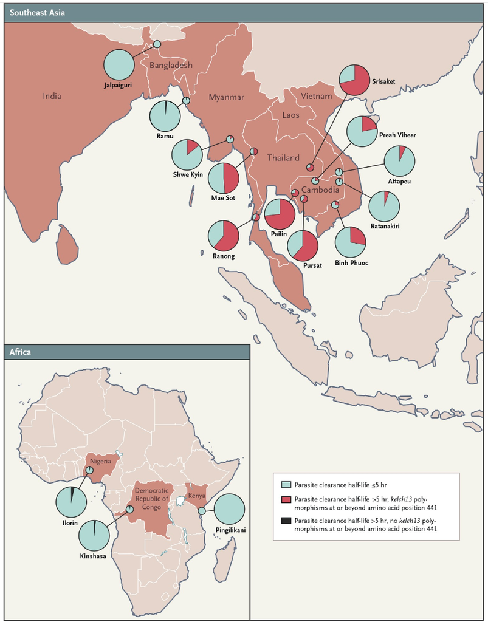

From Ashley et al. (2014)

Rosenthal (2021): “Recent data suggest that we are on the verge of clinically meaningful artemisinin-resistance in Africa”

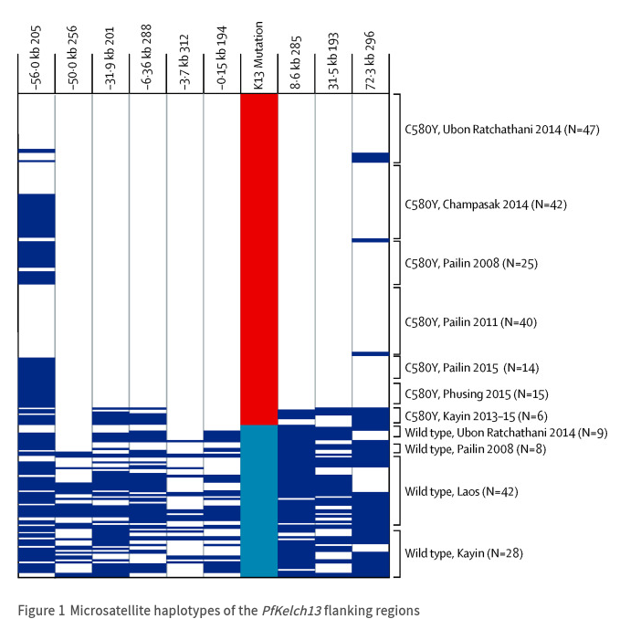

> From Imwong et al. (2017). Red box=C580Y. Light blue box=wild type. Each row represents one parasite isolate; white cells indicate identical microsatellite alleles compared with the most frequent allele and dark blue cells indicate differences. containment strategies: eliminate *falciparum* malaria from Greater Mekong region or “firewall”?

## vectors and resistance to insecticides

- DDT [Wikipedia](https://en.wikipedia.org/wiki/DDT#Mosquito_resistance)
  - environmental side effects
    - fast evolution of resistance: 6-7 years (Gladwell, 2001)
- other methods?
  - sterile male release (irradiation, *Wolbachia*) (Atyame et al., 2016)
  - **gene drive** (Burt et al., 2018) and/or bacterial infection (Dennison et al., 2014)
    - reduce vector competence
    - shift sex ratios toward males
  - evolution-resistant insecticides: shorten host life span (Koella et al., 2009; McMeniman et al., 2009)
    - weak selection against late-acting processes (Medawar, 2019)
    - late-acting insecticides (W. or fungal)
    - larvicides: resistant phenotypes are smaller/short-lived

## References

Achan, J., Talisuna, A. O., Erhart, A., Yeka, A., Tibenderana, J. K., Baliraine, F. N., Rosenthal, P. J., & D’Alessandro, U. (2011). Quinine, an old anti-malarial drug in a modern world: Role in the treatment of malaria. *Malaria Journal*, *10*(1), 144. https://doi.org/10.1186/1475-2875-10-144

Adam, H. J., Richardson, S. E., Jamieson, F. B., Rawte, P., Low, D. E., & Fisman, D. N. (2010). Changing epidemiology of invasive *Haemophilus influenzae* in Ontario, Canada: Evidence for herd effects and strain replacement due to Hib vaccination. *Vaccine*, *28*(24), 4073–4078. https://doi.org/10.1016/j.vaccine.2010.03.075

Ashley, E. A., Dhorda, M., Fairhurst, R. M., Amaratunga, C., Lim, P., Suon, S., Sreng, S., Anderson, J. M., Mao, S., Sam, B., Sopha, C., Chuor, C. M., Nguon, C., Sovannaroth, S., Pukrittayakamee, S., Jittamala, P., Chotivanich, K., Chutasmit, K., Suchatsoonthorn, C., … White, N. J. (2014). Spread of Artemisinin Resistance in Plasmodium falciparum Malaria. *New England Journal of Medicine*, *371*(5), 411–423. https://doi.org/10.1056/NEJMoa1314981

Atyame, C. M., Labbé, P., Lebon, C., Weill, M., Moretti, R., Marini, F., Gouagna, L. C., Calvitti, M., & Tortosa, P. (2016). Comparison of irradiation and Wolbachia based approaches for sterile-male strategies targeting *Aedes albopictus*. *PLOS ONE*, *11*(1), e0146834. https://doi.org/10.1371/journal.pone.0146834

Benveniste, R., & Davies, J. (1973). Aminoglycoside Antibiotic-Inactivating Enzymes in Actinomycetes Similar to Those Present in Clinical Isolates of Antibiotic-Resistant Bacteria. *Proceedings of the National Academy of Sciences*, *70*(8), 2276–2280. https://doi.org/10.1073/pnas.70.8.2276

Bergstrom, C. T., Lo, M., & Lipsitch, M. (2004). Ecological theory suggests that antimicrobial cycling will not reduce antimicrobial resistance in hospitals. *Proceedings of the National Academy of Sciences*, *101*(36), 13285–13290. https://doi.org/10.1073/pnas.0402298101

Bjorkholm, B., Sjölund, M., Falk, P. G., Berg, O. G., Engstrand, L., & Andersson, D. I. (2001). Mutation frequency and biological cost of antibiotic resistance in *Helicobacter pylori*. *Proceedings of the National Academy of Sciences of the United States of America*, *98*(25), 14607–14612. https://doi.org/10.1073/pnas.241517298

Bonhoeffer, S., Coffin, J. M., & Nowak, M. A. (1997). Human immunodeficiency virus drug therapy and virus load. *Journal of Virology*, *71*(4), 3275–3278. http://www.ncbi.nlm.nih.gov/pmc/articles/PMC191463/

Bonhoeffer, S., Lipsitch, M., & Levin, B. R. (1997). Evaluating treatment protocols to prevent antibiotic resistance. *Proceedings of the National Academy of Sciences*, *94*(22), 12106–12111. https://doi.org/10.1073/pnas.94.22.12106

Burt, A., Coulibaly, M., Crisanti, A., Diabate, A., & Kayondo, J. K. (2018). Gene drive to reduce malaria transmission in sub-Saharan Africa. *Journal of Responsible Innovation*, *5*(sup1), S66–S80. https://doi.org/10.1080/23299460.2017.1419410

Centers for Disease Control. (2020). *Extensively Drug-Resistant Tuberculosis (XDR TB)*. https://www.cdc.gov/tb/publications/factsheets/drtb/xdrtb.htm

Covert, C., Ding, L., Brown, D., Franco, E. L., Bernstein, D. I., & Kahn, J. A. (2019). Evidence for cross-protection but not type-replacement over the 11 years after human papillomavirus vaccine introduction. *Human Vaccines & Immunotherapeutics*.

D’Costa, V. M., King, C. E., Kalan, L., Morar, M., Sung, W. W. L., Schwarz, C., Froese, D., Zazula, G., Calmels, F., Debruyne, R., Golding, G. B., Poinar, H. N., & Wright, G. D. (2011). Antibiotic resistance is ancient. *Nature*, *477*(7365), 457–461. https://doi.org/10.1038/nature10388

Dennison, N. J., Jupatanakul, N., & Dimopoulos, G. (2014). The mosquito microbiota influences vector competence for human pathogens. *Current Opinion in Insect Science*, *3*, 6–13. https://doi.org/10.1016/j.cois.2014.07.004

Ebmeyer, S., Kristiansson, E., & Larsson, D. G. J. (2021). A framework for identifying the recent origins of mobile antibiotic resistance genes. *Communications Biology*, *4*(1), 1–10. https://doi.org/10.1038/s42003-020-01545-5

Eggleton, J. S., & Nagalli, S. (2022). Highly Active Antiretroviral Therapy (HAART). In *StatPearls*. StatPearls Publishing. http://www.ncbi.nlm.nih.gov/books/NBK554533/

Ferguson, N., Ghani, A., Cori, A., Hogan, A., Hinsley, W., & Volz, E. (2021). Report 49 - Growth, population distribution and immune escape of Omicron in England. In *Imperial College London*. http://www.imperial.ac.uk/medicine/departments/school-public-health/infectious-disease-epidemiology/mrc-global-infectious-disease-analysis/covid-19/report-49-omicron/

Finken, M., Kirschner, P., Meier, A., Wrede, A., & Böttger, E. C. (1993). Molecular basis of streptomycin resistance in *Mycobacterium tuberculosis*: Alterations of the ribosomal protein S12 gene and point mutations within a functional 16S ribosomal RNA pseudoknot. *Molecular Microbiology*, *9*(6), 1239–1246. https://doi.org/10.1111/j.1365-2958.1993.tb01253.x

Gladwell, M. (2001). The Mosquito Killer. *The New Yorker*. https://web.archive.org/web/20160416165010/http://gladwell.com/the-mosquito-killer/

Imwong, M., Suwannasin, K., Kunasol, C., Sutawong, K., Mayxay, M., Rekol, H., Smithuis, F. M., Hlaing, T. M., Tun, K. M., Pluijm, R. W. van der, Tripura, R., Miotto, O., Menard, D., Dhorda, M., Day, N. P. J., White, N. J., & Dondorp, A. M. (2017). The spread of artemisinin-resistant Plasmodium falciparum in the Greater Mekong subregion: A molecular epidemiology observational study. *The Lancet Infectious Diseases*, *17*(5), 491–497. https://doi.org/10.1016/S1473-3099(17)30048-8

Jarry, J. (2021). The Malaria Vaccine’s Success Story Hides Legitimate Concerns. In *McGill University Office for Science and Society*. https://www.mcgill.ca/oss/article/health-and-nutrition/malaria-vaccines-success-story-hides-legitimate-concerns

Karwehl, S., & Stadler, M. (2016). Exploitation of Fungal Biodiversity for Discovery of Novel Antibiotics. In M. Stadler & P. Dersch (Eds.), *How to Overcome the Antibiotic Crisis : Facts, Challenges, Technologies and Future Perspectives* (pp. 303–338). Springer International Publishing. https://doi.org/10.1007/82_2016_496

Koella, J. C., Lynch, P. A., Thomas, M. B., & Read, A. F. (2009). Towards evolution-proof malaria control with insecticides. *Evolutionary Applications*, *2*(4), 469–480. https://doi.org/10.1111/j.1752-4571.2009.00072.x

Levin, B. R., Perrot, V., & Walker, N. (2000). Compensatory mutations, antibiotic resistance and the population genetics of adaptive evolution in bacteria. *Genetics*, *154*(3), 985–997.

Lipsitch, M., & Samore, M. H. (2002). Antimicrobial Use and Antimicrobial Resistance: A Population Perspective. *Emerging Infectious Diseases*, *8*(4), 347–354. https://doi.org/10.3201/eid0804.010312

Lipsitch, M., Singer, R. S., & Levin, B. R. (2002). Antibiotics in agriculture: When is it time to close the barn door? *Proceedings of the National Academy of Sciences of the United States of America*, *99*(9), 5752–5754. https://doi.org/10.1073/pnas.092142499

Llewelyn, M. J., Fitzpatrick, J. M., Darwin, E., SarahTonkin-Crine, Gorton, C., Paul, J., Peto, T. E. A., Yardley, L., Hopkins, S., & Walker, A. S. (2017). The antibiotic course has had its day. *BMJ*, *358*, j3418. https://doi.org/10.1136/bmj.j3418

Man, I., Vänskä, S., Lehtinen, M., & Bogaards, J. A. (2021). Human papillomavirus genotype replacement: Still too early to tell? *The Journal of Infectious Diseases*, *224*(3), 481–491.

Mavrich, T. N., & Hatfull, G. F. (2017). Bacteriophage evolution differs by host, lifestyle and genome. *Nature Microbiology*, *2*, 17112. https://doi.org/10.1038/nmicrobiol.2017.112

McMeniman, C. J., Lane, R. V., Cass, B. N., Fong, A. W. C., Sidhu, M., Wang, Y.-F., & O’Neill, S. L. (2009). Stable introduction of a life-shortening Wolbachia infection into the mosquito *Aedes aegypti*. *Science*, *323*(5910), 141–144. https://doi.org/10.1126/science.1165326

Medawar, P. B. (2019). *The Uniqueness of the Individual*. Routledge. https://doi.org/10.4324/9780429299759

Musiime, A. K., Krezanoski, P. J., Smith, D. L., Kilama, M., Conrad, M. D., Otto, G., Kyagamba, P., Asiimwe, J., Rek, J., Nankabirwa, J. I., Arinaitwe, E., Akol, A. M., Kamya, M. R., Staedke, S. G., Drakeley, C., Bousema, T., Lindsay, S. W., Dorsey, G., & Tusting, L. S. (2022). House design and risk of malaria, acute respiratory infection and gastrointestinal illness in Uganda: A cohort study. *PLOS Global Public Health*, *2*(3), e0000063. https://doi.org/10.1371/journal.pgph.0000063

Rosenthal, P. J. (2021). Has artemisinin resistance emerged in Africa? *The Lancet Infectious Diseases*, *21*(8), 1056–1057. https://doi.org/10.1016/S1473-3099(21)00168-7

Seo, M. K., Baker, P., & Ngo, K. N.-L. (2014). Cost-effectiveness analysis of vaccinating children in Malawi with RTS,S vaccines in comparison with long-lasting insecticide-treated nets. *Malaria Journal*, *13*(1), 66. https://doi.org/10.1186/1475-2875-13-66

Smith, D. L., Harris, A. D., Johnson, J. A., Silbergeld, E. K., & Morris, J. G. (2002). Animal antibiotic use has an early but important impact on the emergence of antibiotic resistance in human commensal bacteria. *Proceedings of the National Academy of Sciences of the United States of America*, *99*(9), 6434–6439. https://doi.org/10.1073/pnas.082188899

South Africa National Department of Health, R. of. (2019). *2019 ART Clinical Guidelines for the Management of HIV in Adults, Pregnancy, Adolescents, Children, Infants and Neonates*. https://www.nicd.ac.za/wp-content/uploads/2019/11/2019-ART-Clinical-Guidelines-25-Nov.pdf

van Gent, M., Bart, M. J., van der Heide, H. G. J., Heuvelman, K. J., & Mooi, F. R. (2012). Small Mutations in *Bordetella pertussis* Are Associated with Selective Sweeps. *PLOS ONE*, *7*(9), e46407. https://doi.org/10.1371/journal.pone.0046407

Wang, W.-C., Sayedahmed, E. E., Sambhara, S., & Mittal, S. K. (2022). Progress towards the Development of a Universal Influenza Vaccine. *Viruses*, *14*(8), 1684. https://doi.org/10.3390/v14081684

Wu, J., Meng, L., Gaïa, M., Hikida, H., Okazaki, Y., Endo, H., & Ogata, H. (2023). *Gene transfer among viruses substantially contributes to gene gain of giant viruses* (p. 2023.09.26.559659). bioRxiv. https://doi.org/10.1101/2023.09.26.559659

Last updated: 2025-11-23 17:05:03.097219